# An Introduction to Statistical Learning (2013)

Solutions to Exercises

by Brian Hassett

# Chapter 3 Conceptual Exercises

This notebook outlines solutions to the conceptual exercises in Chapter 3 of **An Introduction to Statistical Learning** (James et al. (2013)[^1]).

## Exercise 1

We have a multiple linear regression model with three predictors:
$$Y=\beta_{0}+\beta_{1}X_{1}+\beta_{2}X_{2}+\beta_{3}X_{3}+\epsilon$$

Our response variable is `sales`. Our three predictors are `TV`, `radio` and `newspaper`. Using our model we can predict sales using the estimated $\beta$-coefficients:
$$\widehat{\texttt{sales}} = \hat{\beta}_{0}+\hat{\beta}_{1}\texttt{TV}+\hat{\beta}_{2}\texttt{radio}+\hat{\beta}_{3}\texttt{newspaper}$$
Our null hypothesis, $H_{0}$, is that our the true $\beta$-coefficients are all equal to zero:

$$H_{0}:\beta_{1}=\beta_{2}=\beta_{3}=0$$
From Table3.4 we can draw the following conclusions:
1. `TV`: The null hypothesis is that expenditure on TV advertising has no effect on sales: $H_{0}^{(1)}:\beta_{1}=0$. The table shows a very low p-value for the `TV` predictor (<0.0001). Therefore we can **reject the null hypothesis** and conclude that there is a statistically significant association between `TV` and `sales`.
2. `radio`: The null hypothesis is that expenditure on radio advertising has no effect on sales: $H_{0}^{(2)}:\beta_{2}=0$. The table shows a very low p-value for the `radio` predictor (<0.0001). Therefore we can **reject the null hypothesis** and conclude that there is a statistically significant association between `radio` and `sales`.
3. `newspaper`: The null hypothesis is that expenditure on newspaper advertising has no effect on sales: $H_{0}^{(3)}:\beta_{3}=0$. The table shows a large p-value for the `newspaper` predictor (0.8599). Therefore we **cannot** reject the null hypothesis. We conclude that there is no v significant association between `newspaper` and `sales`.

## Exercise 3

We construct a model
$$Y=\beta_{0}+\beta_{1}X_{1}+\beta_{2}X_{2}+\beta_{3}X_{3}+\beta_{4}X_{4}+\beta_{5}X_{5}+\epsilon,$$
where $Y=\texttt{salary}$, $X_{1}=\texttt{GPA}$, $X_{2}=\texttt{IQ}$, $X_{3}=\texttt{Gender}$ ($\texttt{1}$ for Female, $\texttt{0}$ for Male), $X_{4}=\texttt{GPA:IQ}$, and $X_{5}=\texttt{GPA:Gender}$.

After fitting the model via least squares we have $\hat{\beta}_{0}=50$, $\hat{\beta}_{1}=20$, $\hat{\beta}_{2}=0.07$, $\hat{\beta}_{3}=35$, $\hat{\beta}_{4}=0.01$, $\hat{\beta}_{5}=-10$.

Using our model we can make predictions for $\texttt{salary}$:
$$\widehat{\texttt{salary}}\ = 50+20\times\texttt{GPA}+0.07\times\texttt{IQ}+0.01\times\texttt{GPA}\times\texttt{IQ}+\begin{cases}0 & \text{if }\texttt{Gender}=0\text{ (Male)} \\35-10\times\texttt{GPA} & \text{if }\texttt{Gender}=1\text{ (Female)}\end{cases}$$

Tidying up the terms we get:
$$\widehat{\texttt{salary}}\ = 0.07\times\texttt{IQ}+0.01\times\texttt{GPA}\times\texttt{IQ}+\begin{cases}50+20\times\texttt{GPA}& \text{if }\texttt{Gender}=0\text{ (Male)} \\85+10\times\texttt{GPA} & \text{if }\texttt{Gender}=1\text{ (Female)}\end{cases}$$

### (a)

According to the model, the starting salary **will be the same** for a male or female graduate when $50+20\times\texttt{GPA}=85+10\times\texttt{GPA}$; i.e. when $\texttt{GPA}=3.5$. For a fixed value of $\texttt{IQ}$ and $\texttt{GPA}$, males earn more on average than females provided that $\texttt{GPA}>3.5$. When $\texttt{GPA}<3.5$, females earn more. And as we already stated, when $\texttt{GPA}=3.5$ they earn the same. Therefore point (iii) is correct.

This is evident in the below plots showing the starting salary for a range of values of $\texttt{GPA}$ and $\texttt{IQ}$. The starting salary for males varies more across the range of values for $\texttt{GPA}$:

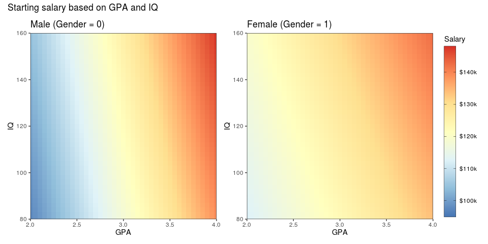

```r
GPA <- seq(2.0, 4.0, by = 0.05)
IQ <- seq(80, 160, by = 2)

male <- expand_grid(GPA, IQ) %>%
  mutate(salary = 50 + 20*GPA + 0.07*IQ + 35*0 + 0.01*GPA*IQ + (-10)*GPA*0)
female <- expand_grid(GPA, IQ) %>%
  mutate(salary = 50 + 20*GPA + 0.07*IQ + 35*1 + 0.01*GPA*IQ + (-10)*GPA*1)

p1 <- ggplot(male, aes(GPA, IQ)) +
  geom_raster(interpolate = F, aes(fill = salary)) +
  scale_fill_distiller(type = "div", palette = 7, direction = -1,
                       breaks = seq(100, 150, by = 10),
                       limits = c(95, 148),
                       labels = scales::dollar(seq(100, 150, by = 10), suffix = 'k')) +
  coord_cartesian(xlim = c(GPA[1], GPA[length(GPA)]), ylim = c(IQ[1], IQ[length(IQ)]), expand = FALSE) +
  theme_bw() +
  labs(x = "GPA", y = "IQ",
       title = "Male (Gender = 0)") +
  guides(fill = guide_colourbar("Salary",
                                barheight = unit(3.5, "in"),
                                ticks.colour = "black",
                                frame.colour = "black"))

p2 <- ggplot(female, aes(GPA, IQ)) +
  geom_raster(interpolate = F, aes(fill = salary)) +
  scale_fill_distiller(type = "div", palette = 7, direction = -1,
                       breaks = seq(100, 150, by = 10),
                       limits = c(95, 148),
                       labels = scales::dollar(seq(100, 150, by = 10), suffix = 'k')) +
  coord_cartesian(xlim = c(GPA[1], GPA[length(GPA)]), ylim = c(IQ[1], IQ[length(IQ)]), expand = FALSE) +
  theme_bw() +
  labs(x = "GPA", y = "IQ",
       title = "Female (Gender = 1)") +
  guides(fill = guide_colourbar("Salary",
                                barheight = unit(3.5, "in"),
                                ticks.colour = "black",
                                frame.colour = "black"))

p1 + p2 + plot_annotation(title = "Starting salary based on GPA and IQ") +
  plot_layout(guides = "collect")
```

### (b)

Use the above model to predict the $\texttt{salary}$ of a female graduate $(\texttt{Gender = 1})$, when $\texttt{IQ}$ is 110 and $\texttt{GPA}$ is 4.0:

```r
gpa <- 4.0
iq <- 110
salary <- 50 + 20*gpa + 0.07*iq + 35*1 + 0.01*gpa*iq + (-10)*gpa*1
salary
```

This gives a starting salary of **$137,100**.

### (c)

False. The value of the $\beta$-coefficient isn’t enough to determine whether or not there is evidence of an interaction effect, ie whether or not to reject the null hypothesis $H_{0}:\beta_{4}=0$. To do this we need the corresponding t-statistic (and p-value).

## Exercise 4

### (a)

The cubic regression model would have a lower training RSS. The cubic model is more flexible than the linear model. Hence, the cubic model can fit the data more closely during training and achieve a lower RSS.

### (b)

The linear regression model would have a lower test RSS. In general, more flexible models have lower bias and higher variance, and are prone to overfitting the training data. In contrast, less flexible models have high bias and lower variance. In this case the true relationship between the predictor and the response is linear. Therefore the linear model will have lower test RSS than the cubic regression model (which may have overfit the training data).

### (c)

The cubic regression model would have a lower training RSS. The cubic regression model is more flexible than the linear regression model. Hence, the cubic model can fit the data more closely during training and achieve a lower RSS.

### (d)

Not enough information to tell. Depending on how non-linear the true relationship is, either model could perform better. If the relationship is highly non-linear (with low noise) the cubic model will have a lower RSS. However, if the relationship is only slightly non-linear (or the noise in our training data is high) then the linear regression might have lower RSS. Overall we need to consider the bias-variance trade-off of the models, and the size of the training set and the magnitude of the noise.

## Exercise 5

Given:
$$\hat{y_i}~=~x_i\hat{\beta},$$
where
$$\hat{\beta} ~=~ \left( \sum_{i=1}^n x_{i} y_{i} \right) / \left( \sum_{i'=1}^n x_{i'}^2 \right).$$

Substitute the expression for $\hat{\beta}$ into the formula for $\hat{y_{i}}$:

$$\hat{y}_i ~=~ x_i \hat{\beta} ~=~ x_i \left( \sum_{i'=1}^n x_{i'} y_{i'} \right) / \left( \sum_{j=1}^n x_j^2 \right).$$

Move $x_{i}$ (a constant) inside the summation:
$$\hat{y}_i ~=~ \left( \sum_{i'=1}^n x_{i}x_{i'} y_{i'} \right) / \left( \sum_{j=1}^n x_j^2 \right).$$

Rearrange:
$$\hat{y}_i ~=~ \sum_{i'=1}^n \left( \frac{x_i x_{i'} }{\sum_{j=1}^n x_j^2} y_{i'} \right)$$
Rewrite as
$$\hat{y}_i ~=~ \sum_{i'=1}^n a_{i'} y_{i'}$$

where
$$a_{i'} ~=~ \frac{x_i x_{i'} }{\sum_{j=1}^n x_j^2} \hspace{2cm} \square$$

## Exercise 6

Equation (3.4) gives us
$$\hat{\beta}_{1} ~=~ \frac{\sum_{i=1}^n(x_{i}-\bar{x})(y_{i}-\bar{y})}{\sum_{i=1}^n(x_{i}-\bar{x})^2},$$
$$\hat{\beta}_{0} ~=~ \bar{y}-\hat{\beta}_{1}\bar{x},$$
where $\bar{y}\equiv\frac{1}{n}\sum_{i=1}^ny_{i}$ and $\bar{x}\equiv\frac{1}{n}\sum_{i=1}^nx_{i}$ are the sample means.

Our regression line is given by
$$\hat{y}=\hat{\beta}_{0}+\hat{\beta_{1}}x.$$
If the point ($\bar{x}$, $\bar{y}$) is on the regression line, then
$$\bar{y}=\hat{\beta}_{0}+\hat{\beta_{1}}\bar{x}$$
Substitute in the expression for $\hat{\beta}_{0}$ given by (3.4):
$$\bar{y}=\left(\bar{y}-\hat{\beta}_{1}\bar{x}\right)+\hat{\beta_{1}}\bar{x}$$
The $\bar{x}$ terms cancel out, leaving
$$\bar{y}=\bar{y}$$
This proves that the point ($\bar{x}$, $\bar{y}$) is always on the regression line.

## Exercise 7

**Preliminaries**
From equation (3.16):
$$\begin{equation}\text{RSS}=\sum_{i=1}^n(y_{i}-\hat{y}_{i})^2\end{equation}$$

From equation (3.17):
$$R^2=1-\frac{\text{RSS}}{\text{TSS}},$$
where
$$\text{TSS}=\sum_{i=1}^n(y_{i}-\bar{y})^2$$

From equation (3.18):
$$\text{Cor}(X,Y)=\frac{\sum_{i=1}^n(x_{i}-\bar{x})(y_{i}-\bar{y})}{\sqrt{\sum_{i=1}^n(x_{i}-\bar{x})^2}\sqrt{\sum_{i=1}^n(y_{i}-\bar{y})^2}}$$

**To prove**
Asumming $\bar{x}=\bar{y}=0$, show:
$$R^2=\text{Cor}(X,Y)^2$$
**Proof**
**(1)**
Firstly, we note that equation (3.16) for $\text{RSS}$ contains a $\hat{y}_{i}$ term. Using $\hat{y_{i}}=\hat{\beta}_{0}+\hat{\beta_{1}}x_{i}$, rewrite equation (3.16) in terms of $x_{i}$:
$$\text{RSS}=\sum_{i=1}^n(y_{i}-(\hat{\beta}_{0}+\hat{\beta_{1}}x_{i}))^2$$

From (3.4) we have expressions for $\hat{\beta}_{0}$ and $\hat{\beta}_{1}$:

$$\hat{\beta}_{1} ~=~ \frac{\sum_{i=1}^n(x_{i}-\bar{x})(y_{i}-\bar{y})}{\sum_{i=1}^n(x_{i}-\bar{x})^2},$$
$$\hat{\beta}_{0} ~=~ \bar{y}-\hat{\beta}_{1}\bar{x}$$

We know that $\bar{x}=\bar{y}=0$. This gives us:
$$\hat{\beta}_{1} ~=~ \frac{\sum_{i=1}^nx_{i}y_{i}}{\sum_{i=1}^n(x_{i})^2},$$
$$\hat{\beta}_{0} ~=~ 0$$

With $\hat{\beta}_{0}=0$, expand the equation for $\text{RSS}$:
$$\text{RSS}=\sum_{i=1}^n(y_{i}-(0+\hat{\beta_{1}}x_{i}))^2$$
$$\text{RSS}=\sum_{i=1}^n(y_{i}^2-2\hat{\beta}_{1}x_{i}y_{i}+\hat{\beta}_{1}^2x_{i}^2)$$

Substitute in the expression for $\hat{\beta}_{1}$ (remember to update indexes of the nested sums):
$$\text{RSS}=\sum_{i=1}^n(y_{i}^2-2\frac{\sum_{j=1}^nx_{j}y_{j}}{\sum_{j=1}^n(x_{j})^2}x_{i}y_{i}+\frac{\left(\sum_{j=1}^nx_{j}y_{j}\right)^2}{\left(\sum_{j=1}^n(x_{j})^2\right)^2}x_{i}^2)$$

Expand the sum and rearrange:
$$\text{RSS}=\sum_{i=1}^n(y_{i})^2-2\frac{\sum_{j=1}^nx_{j}y_{j}}{\sum_{j=1}^n(x_{j})^2}\sum_{i=1}^nx_{i}y_{i}+\frac{\left(\sum_{j=1}^nx_{j}y_{j}\right)^2}{\left(\sum_{j=1}^n(x_{j})^2\right)^2}\sum_{i=1}^nx_{i}^2$$
There are no nested sums, so indexes $i$ and $j$ are the same. Rewrite with index $i$ and rearrange:
$$\text{RSS}=\sum_{i=1}^n(y_{i})^2-2\frac{\left(\sum_{i=1}^nx_{i}y_{i}\right)^2}{\sum_{i=1}^n(x_{i})^2}+\frac{\left(\sum_{i=1}^nx_{i}y_{i}\right)^2\sum_{i=1}^n(x_{i})^2}{\sum_{i=1}^n(x_{i})^2\sum_{i=1}^n(x_{i})^2}$$
Cancel terms and simplify :
$$\text{RSS}=\sum_{i=1}^n(y_{i})^2-\frac{\left(\sum_{i=1}^nx_{i}y_{i}\right)^2}{\sum_{i=1}^n(x_{i})^2}$$
**(2)**
Rewrite equation (3.17) with this new expression for $\text{RSS}$:
$$R^2=1-\frac{\sum_{i=1}^n(y_{i})^2-\frac{\left(\sum_{i=1}^nx_{i}y_{i}\right)^2}{\sum_{i=1}^n(x_{i})^2}}{\sum_{i=1}^n(y_{i}-\bar{y})^2}$$
Use $\bar{y}=0$, and rewrite the RHS as one fraction:
$$R^2=\frac{\sum_{i=1}^n(y_{i})^2-\sum_{i=1}^n(y_{i})^2+\frac{\left(\sum_{i=1}^nx_{i}y_{i}\right)^2}{\sum_{i=1}^n(x_{i})^2}}{\sum_{i=1}^n(y_{i})^2}$$

Cancel terms, then simplify the fraction:
$$R^2=\frac{\left(\sum_{i=1}^nx_{i}y_{i}\right)^2}{\sum_{i=1}^n(x_{i})^2\sum_{i=1}^n(y_{i})^2}$$
**(3)**
Returning to equation (3.18) for $\text{Cor}(X,Y)$, rewrite it given $\bar{x}=\bar{y}=0$
$$\text{Cor}(X,Y)=\frac{\sum_{i=1}^n(x_{i}-0)(y_{i}-0)}{\sqrt{\sum_{i=1}^n(x_{i}-0)^2}\sqrt{\sum_{i=1}^n(y_{i}-0)^2}}$$

$$\text{Cor}(X,Y)=\frac{\sum_{i=1}^nx_{i}y_{i}}{\sqrt{\sum_{i=1}^n(x_{i})^2}\sqrt{\sum_{i=1}^n(y_{i})^2}}$$

**(4)**
Finally, use the expressions derived for $R^2$ and $\text{Cor}(X,Y)$ in **(2)** and **(3)** to complete the proof:
$$R^2=\text{Cor}(X,Y)^2$$
$$\frac{\left(\sum_{i=1}^nx_{i}y_{i}\right)^2}{\sum_{i=1}^n(x_{i})^2\sum_{i=1}^n(y_{i})^2}=\left(\frac{\sum_{i=1}^nx_{i}y_{i}}{\sqrt{\sum_{i=1}^n(x_{i})^2}\sqrt{\sum_{i=1}^n(y_{i})^2}}\right)^2$$
$$\frac{\left(\sum_{i=1}^nx_{i}y_{i}\right)^2}{\sum_{i=1}^n(x_{i})^2\sum_{i=1}^n(y_{i})^2}=\frac{\left(\sum_{i=1}^nx_{i}y_{i}\right)^2}{\left(\sqrt{\sum_{i=1}^n(x_{i})^2}\right)^2\left(\sqrt{\sum_{i=1}^n(y_{i})^2}\right)^2}$$
$$\frac{\left(\sum_{i=1}^nx_{i}y_{i}\right)^2}{\sum_{i=1}^n(x_{i})^2\sum_{i=1}^n(y_{i})^2}=\frac{\left(\sum_{i=1}^nx_{i}y_{i}\right)^2}{\sum_{i=1}^n(x_{i})^2\sum_{i=1}^n(y_{i})^2} \hspace{2cm} \square$$

[^1]: James G, Witten D, Hastie T, Tibshirani R (2013). *An Introduction to Statistical Learning: with Applications in R*. Springer, 1st edition.